# Determining the Fat Levels of Canadian Cheese Using Machine Learning Algorithms

## Introduction

The purpose of the project is to fit and find the best machine learning model to predict the fat level of given Canadian cheeses.

## Exploratory Data Analysis

Let's begin by importing all the necessary libraries and the cheese dataset.

```python
#importing required libraries
import pandas as pd
import numpy as np
import altair as alt
from sklearn.model_selection import train_test_split, cross_validate
from sklearn.dummy import DummyClassifier
from sklearn.tree import DecisionTreeClassifier
from sklearn.neighbors import KNeighborsClassifier
from sklearn.ensemble import RandomForestClassifier
from sklearn.svm import SVC
from sklearn.linear_model import LogisticRegression
from sklearn.impute import SimpleImputer
from sklearn.pipeline import make_pipeline
from sklearn.compose import make_column_transformer
from sklearn.preprocessing import OneHotEncoder, OrdinalEncoder, StandardScaler
from sklearn.model_selection import GridSearchCV, RandomizedSearchCV
from sklearn.metrics import plot_confusion_matrix, classification_report
from sklearn.metrics import make_scorer, recall_score, f1_score, precision_score, accuracy_score

#import dataset
cheese = pd.read_csv('data/cheese_data.csv')
```

Below is what the dataset looks like.

```python
cheese.head()
```

|  | CheeseId | ManufacturerProvCode | ManufacturingTypeEn | MoisturePercent | FlavourEn | CharacteristicsEn | Organic | CategoryTypeEn | MilkTypeEn | MilkTreatmentTypeEn | RindTypeEn | CheeseName | FatLevel |
| --- | --- | --- | --- | --- | --- | --- | --- | --- | --- | --- | --- | --- | --- |
| 0 | 228 | NB | Farmstead | 47.0 | Sharp, lactic | Uncooked | 0 | Firm Cheese | Ewe | Raw Milk | Washed Rind | Sieur de Duplessis (Le) | lower fat |
| 1 | 242 | NB | Farmstead | 47.9 | Sharp, lactic, lightly caramelized | Uncooked | 0 | Semi-soft Cheese | Cow | Raw Milk | Washed Rind | Tomme Le Champ Doré | lower fat |
| 2 | 301 | ON | Industrial | 54.0 | Mild, tangy, and fruity | Pressed and cooked cheese, pasta filata, inter... | 0 | Firm Cheese | Cow | Pasteurized | NaN | Provolone Sette Fette (Tre-Stelle) | lower fat |
| 3 | 303 | NB | Farmstead | 47.0 | Sharp with fruity notes and a hint of wild honey | NaN | 0 | Veined Cheeses | Cow | Raw Milk | NaN | Geai Bleu (Le) | lower fat |
| 4 | 319 | NB | Farmstead | 49.4 | Softer taste | NaN | 1 | Semi-soft Cheese | Cow | Raw Milk | Washed Rind | Gamin (Le) | lower fat |

**Table 1:** First 5 rows of the cheese dataset

```python
cheese.info()
```

```
<class 'pandas.core.frame.DataFrame'>
RangeIndex: 1042 entries, 0 to 1041
Data columns (total 13 columns):
 #   Column                Non-Null Count  Dtype
---  ------                --------------  -----
 0   CheeseId              1042 non-null   int64
 1   ManufacturerProvCode  1042 non-null   object
 2   ManufacturingTypeEn   1042 non-null   object
 3   MoisturePercent       1028 non-null   float64
 4   FlavourEn             801 non-null    object
 5   CharacteristicsEn     643 non-null    object
 6   Organic               1042 non-null   int64
 7   CategoryTypeEn        1019 non-null   object
 8   MilkTypeEn            1041 non-null   object
 9   MilkTreatmentTypeEn   977 non-null    object
 10  RindTypeEn            721 non-null    object
 11  CheeseName            1042 non-null   object
 12  FatLevel              1042 non-null   object
dtypes: float64(1), int64(2), object(10)
memory usage: 106.0+ KB
```

The cheese data consists of 1042 rows and 13 columns. It contains important information on where the cheeses were manufactured, the type of manufacturing done on them, the moisture percentage, the flavours and characteristics, the type of cheese, the type of milk used and how the milk was treated. The cheese data has one continuous and binary variable, while the rest are of categorical. Not all columns are complete as there are some missing data in some of the columns.

In order to avoid violating the golden rule, the data is split into training and testing sets. The training set consists of 80% of the original data whereas the testing set consists of 20%.

```python
train_df, test_df = train_test_split(cheese, test_size = 0.2, random_state = 123)

fat_chart = alt.Chart(train_df, width = 500, height = 300).mark_bar().encode(
    alt.X("FatLevel:N"),
    alt.Y("count():Q")
).properties(title = "Count of Fat Levels")
fat_chart
```

[interactive chart not shown]

**Figure 1:** Recorded counts of unique values in the target column FatLevel of the training dataset

*MoisturePercent* is the only quantitative feature and is used to display the distribution of the data based on the target values "higher fat" and "lower fat."

```python
histogram = alt.Chart(train_df).mark_bar(opacity=0.7).encode(
            alt.X("MoisturePercent:Q", bin=alt.Bin(maxbins=50)),
            alt.Y("count()", stack=None),
            alt.Color("FatLevel:N"),
).properties(title=str.title("MoisturePercent"))
histogram
```

[interactive chart not shown]

**Figure 2:** Distribution of *MoisturePercent* for FatLevel.

Figure 2 shows how *MoisturePercent* is distributed and how it is classified as either "higher fat" or "lower fat." Generally, cheeses with more than 40% moisture are classified "lower fat," whereas cheeses with 40% or lower moisture are classified as "higher fat."

Moving on, the training and testing data are split into their respective features and target while dropping any unnecessary columns.

```python
X_train, y_train = train_df.drop(columns = ["CheeseId", "ManufacturerProvCode", "FlavourEn", "CharacteristicsEn",
                                            "MilkTypeEn", "RindTypeEn", "CheeseName", "FatLevel"]), train_df["FatLevel"]
X_test, y_test = test_df.drop(columns = ["CheeseId", "ManufacturerProvCode", "FlavourEn", "CharacteristicsEn",
                                         "MilkTypeEn", "RindTypeEn", "CheeseName", "FatLevel"]), test_df["FatLevel"]
```

```python
X_train.info()
```

```
<class 'pandas.core.frame.DataFrame'>
Int64Index: 833 entries, 482 to 1041
Data columns (total 5 columns):
 #   Column               Non-Null Count  Dtype
---  ------               --------------  -----
 0   ManufacturingTypeEn  833 non-null    object
 1   MoisturePercent      821 non-null    float64
 2   Organic              833 non-null    int64
 3   CategoryTypeEn       813 non-null    object
 4   MilkTreatmentTypeEn  781 non-null    object
dtypes: float64(1), int64(1), object(3)
memory usage: 39.0+ KB
```

## Methods and Results

Before finding the best estimator, the dummy classifier with the strategy "most_frequent" is used as a basline model.

```python
dummy_clf = DummyClassifier(strategy = "most_frequent")
dummy_clf.fit(X_train, y_train)
print("training score: ", dummy_clf.score(X_train, y_train))
```

```
training score:  0.6578631452581032
```

The baseline model dummy classifier has a validation score of 0.66.

Before testing out various models, the columns are categorized as their respective features and transformed.

Machine Learning algorithms require numeric inputs, so the categorical variables are converted into numeric values using OneHotEncoder and OrdinalEncoder. The columns *CategoryTypeEn* and *MilkTreatmentTypeEn* appear to be of ordinal; thus, they are converted using OrdinalEncoder whereas OneHotEncoder is used for *ManufacturingTypeEn*. The columns *MoisturePercent*, *CategoryTypeEn*, and *MilkTreatmentTypeEn* have missing values; therefore, SimpleImputer is used since the presence of NaN/null values in the data returns error later on in the analysis.

Using make_pipeline and make_column_transformer, the columns are transformed. The transformed data is then be used to build a pipeline that iterates over 5 different classification models to find the best one.

```python
num_feats = ["MoisturePercent"]
cat_feats = ["ManufacturingTypeEn"]
ord_feats = ["CategoryTypeEn", "MilkTreatmentTypeEn"]

num_transformer = make_pipeline(SimpleImputer(strategy = "median"), StandardScaler())
cat_transformer = make_pipeline(OneHotEncoder(dtype = int, handle_unknown = "ignore"))

cat_type_order = ["Fresh Cheese", "Soft Cheese", "Semi-soft Cheese",
                  "Veined Cheeses", "Firm Cheese", "Hard Cheese"]
ord_transformer1 = make_pipeline(SimpleImputer(strategy = "most_frequent"),
                                 OrdinalEncoder(categories=[cat_type_order], dtype=int))

milk_order = ["Raw Milk", "Thermised", "Pasteurized"]
ord_transformer2 = make_pipeline(SimpleImputer(strategy = "most_frequent"),
                                 OrdinalEncoder(categories=[milk_order], dtype=int))

preprocessor = make_column_transformer((num_transformer, num_feats),
                                       (cat_transformer, cat_feats),
                                       (ord_transformer1, ['CategoryTypeEn']),
                                       (ord_transformer2, ['MilkTreatmentTypeEn']))
```

Using a for loop, the transformed data is used to find the best estimator between DecisionTreeClassifier, KNeighborsClassifier, RandomForestClassifier, SVC, and LogisticRegression.

```python
models = {'DTC': DecisionTreeClassifier(random_state = 111), 'KNN': KNeighborsClassifier(),
          'RFC': RandomForestClassifier(class_weight = "balanced", random_state = 111), 'SVC': SVC(), 'LR': LogisticRegression()}
scores = {}

for name, model in models.items():
    pipe = make_pipeline(preprocessor, model)
    scores[name] = pd.DataFrame(cross_validate(pipe, X_train, y_train, cv = 5, return_train_score = True)).mean()

pd.DataFrame(scores)
```

|  | DTC | KNN | RFC | SVC | LR |
| --- | --- | --- | --- | --- | --- |
| fit_time | 0.021052 | 0.020200 | 0.185344 | 0.030809 | 0.025603 |
| score_time | 0.011273 | 0.016885 | 0.023441 | 0.013378 | 0.009501 |
| test_score | 0.793557 | 0.813960 | 0.816384 | 0.783883 | 0.786343 |
| train_score | 0.905766 | 0.855648 | 0.903967 | 0.790817 | 0.789910 |

**Table 2:** Average CV scores of different classifiers

Based on the average validation scores of the classifiers in Table 2, the RandomForestClassifier appears to have predicted the target value better than the other models; therfore, its hyperparameters are tuned using RandomizedSearchCV to further fit the model.

```python
rf_pipe = make_pipeline(preprocessor, RandomForestClassifier(class_weight = "balanced", random_state = 1))

param_grid = {"randomforestclassifier__n_estimators": range(10, 101, 3),
              "randomforestclassifier__max_depth": range(1, 151, 5),}

random_search = RandomizedSearchCV(rf_pipe, param_grid, n_iter = 10, cv = 5,
                                   verbose = 2, n_jobs = -1, random_state = 111)
random_search.fit(X_train, y_train)
```

[output not shown]

```
RandomizedSearchCV(cv=5,
                   estimator=Pipeline(steps=[('columntransformer',
                                              ColumnTransformer(transformers=[('pipeline-1',
                                                                               Pipeline(steps=[('simpleimputer',
                                                                                                SimpleImputer(strategy='median')),
                                                                                               ('standardscaler',
                                                                                                StandardScaler())]),
                                                                               ['MoisturePercent']),
                                                                              ('pipeline-2',
                                                                               Pipeline(steps=[('onehotencoder',
                                                                                                OneHotEncoder(dtype=<class 'int'>,
                                                                                                              handle_unknown='ignore'))])...
                                                                                                OrdinalEncoder(categories=[['Raw '
                                                                                                                            'Milk',
                                                                                                                            'Thermised',
                                                                                                                            'Pasteurized']],
                                                                                                               dtype=<class 'int'>))]),
                                                                               ['MilkTreatmentTypeEn'])])),
                                             ('randomforestclassifier',
                                              RandomForestClassifier(class_weight='balanced',
                                                                     random_state=1))]),
                   n_jobs=-1,
                   param_distributions={'randomforestclassifier__max_depth': range(1, 151, 5),
                                        'randomforestclassifier__n_estimators': range(10, 101, 3)},
                   random_state=111, verbose=2)
```

```python
optimal_parameters = random_search.best_params_
optimal_score = random_search.best_score_
print(optimal_parameters)
print(optimal_score)
```

```
{'randomforestclassifier__n_estimators': 85, 'randomforestclassifier__max_depth': 11}
0.8224009811701898
```

Through the RandomizedSearchCV, the best hyperparameters of the RandomForestClassifier are n_estimator of 85 and max_depth of 11. Using these hyperparameters, the RandomForestClassifier is fitted again and CV of 5 is run with f1, recall, and precision scoring.

```python
# pos_label to indicate which class of FatLevel is positive (higher fat = pos label)
f1 = make_scorer(f1_score, pos_label = "higher fat")
precision = make_scorer(precision_score, pos_label = "higher fat")
recall = make_scorer(recall_score, pos_label = "higher fat")

scoring = {"accuracy": "accuracy", "precision": precision,
           "recall": recall, "f1": f1}
```

```python
rf_pipe = make_pipeline(preprocessor, RandomForestClassifier(n_estimators = optimal_parameters["randomforestclassifier__n_estimators"],
                                                             max_depth = optimal_parameters["randomforestclassifier__max_depth"],
                                                             random_state = 111))
rf_pipe.fit(X_train, y_train)
rf_scores = pd.DataFrame(cross_validate(rf_pipe, X_train, y_train, cv = 5, return_train_score = True,
                                        scoring = scoring))

rf_scores.mean()
```

```
fit_time           0.157782
score_time         0.026984
test_accuracy      0.813967
train_accuracy     0.905766
test_precision     0.736208
train_precision    0.886953
test_recall        0.712281
train_recall       0.832456
test_f1            0.723865
train_f1           0.857532
dtype: float64
```

**Table 3:** Mean cross validation and training score of different hyperparameter turning

Hyperparameter turning through different scoring method shows that precision performed the best (0.736) out of all scoring methods, followed by f1 (0.724), and then recall (0.712).

Using the final estimator, RandomForestClassifier with n_estimator of 85 and max_depth of 11, the features of test data is used to predict the target. The predicted target is then compared with the true target values and a score is calculated.

```python
y_df = pd.DataFrame({"true_y": y_test, "predicted_y": rf_pipe.predict(X_test)})
print(y_df.head())

print("test score: ", rf_pipe.score(X_test, y_test))
```

```
         true_y predicted_y
318   lower fat   lower fat
235  higher fat   lower fat
449  higher fat   lower fat
739   lower fat   lower fat
621   lower fat   lower fat
test score:  0.8229665071770335
```

**Table 4:** Predicted and true target values of the test dataset with test score.

Table 4 displays the comparison between the true target values and the predicted target values. Of the first 5 rows displayed, only 60% of the data are correctly predicted, but the test score of 0.823 indicates that the estimator is fairly precise.

```
<sklearn.metrics._plot.confusion_matrix.ConfusionMatrixDisplay at 0x7f6fb19b3b80>
```

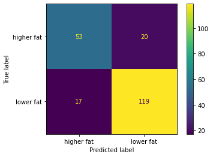

```python
plot_confusion_matrix(rf_pipe, X_test, y_test)
```

The confusion matrix shows that the estimator RandomForestClassifier predicted the testing data to be twice as much *"lower fat"* than *"higher fat"*. Of the predicted *"higher fat"* label, about 75% are labeled correctly as true positives. Similarly, about 85% of the predicted *"lower fat"* labels are correctly labeled as true negatives.

```python
print(classification_report(y_test, rf_pipe.predict(X_test), digits = 3))
```

```
              precision    recall  f1-score   support

  higher fat      0.757     0.726     0.741        73
   lower fat      0.856     0.875     0.865       136

    accuracy                          0.823       209
   macro avg      0.807     0.801     0.803       209
weighted avg      0.822     0.823     0.822       209
```

**Table 5:** Classification report of the target value for the test set

The classification report shows that *"higher fat"* has precision score of 0.757, recall of 0.726, and f1 or 0.741 whereas "*lower fat*" has precision of 0.856, recall of 0.875, and 0.865. The overall accuracy of the prediction is 0.823, which is similar to that of the score recieved from the estimator.

## Discussion

Using columns that are dropped early on in the analysis, such as characteristics and flavours, would help improve the prediction; however, due to time constrait, the columns are not used. Another way to improve the analysis would be to fit and tune the hyperparameters of each model rather than comparing the fits and tuning the best model. In addition, the **canadianCheeseDirectory.csv** file also has another quantitative feature, FatContentPercent, which appears be useful in predicting the target variable FatLevel. The column FatContentPercent could also be used as a quantitative target value for future analyses.

## References

1. [Cheese dataset (link now broken)](https://open.canada.ca/data/en/dataset/3c16cd48-3ac3-453f-8260-6f745181c83b)
2. [UBC Introduction to Machine Learning](https://ml-learn.mds.ubc.ca/en)
3. [scikit learn](https://scikit-learn.org/stable/)
4. [stackoverflow](https://stackoverflow.com/a/39197222)
5. [cheese classification](http://www.ikonet.com/en/visualdictionary/static/us/classification_cheeses)
6. [cheese heat treatment](https://science.howstuffworks.com/life/cellular-microscopic/pasteurization3.htm)